# Project on Iris Dataset

```r
library(datasets)

data(iris)
summary(iris)
```

```
  Sepal.Length    Sepal.Width     Petal.Length    Petal.Width          Species
 Min.   :4.300   Min.   :2.000   Min.   :1.000   Min.   :0.100   setosa    :50
 1st Qu.:5.100   1st Qu.:2.800   1st Qu.:1.600   1st Qu.:0.300   versicolor:50
 Median :5.800   Median :3.000   Median :4.350   Median :1.300   virginica :50
 Mean   :5.843   Mean   :3.057   Mean   :3.758   Mean   :1.199
 3rd Qu.:6.400   3rd Qu.:3.300   3rd Qu.:5.100   3rd Qu.:1.800
 Max.   :7.900   Max.   :4.400   Max.   :6.900   Max.   :2.500
```

```r
dat = iris
str(dat)
```

```
'data.frame':   150 obs. of  5 variables:
 $ Sepal.Length: num  5.1 4.9 4.7 4.6 5 5.4 4.6 5 4.4 4.9 ...
 $ Sepal.Width : num  3.5 3 3.2 3.1 3.6 3.9 3.4 3.4 2.9 3.1 ...
 $ Petal.Length: num  1.4 1.4 1.3 1.5 1.4 1.7 1.4 1.5 1.4 1.5 ...
 $ Petal.Width : num  0.2 0.2 0.2 0.2 0.2 0.4 0.3 0.2 0.2 0.1 ...
 $ Species     : Factor w/ 3 levels "setosa","versicolor",..: 1 1 1 1 1 1 1 1 1 1 ...
```

```r
levels(dat$Species)
```

```
[1] "setosa"     "versicolor" "virginica"
```

```r
percentage <- prop.table(table(dat$Species)) * 100
cbind(freq=table(dat$Species), percentage=percentage)
```

```
           freq percentage
setosa       50   33.33333
versicolor   50   33.33333
virginica    50   33.33333
```

Data Visualization

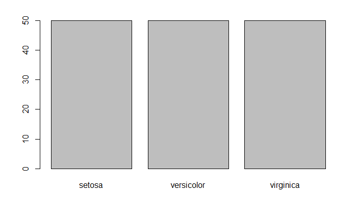

```r
x = dat[1:4]
y = dat[5]
plot(y)
# boxplot for each attribute on one image
par(mfrow=c(1,4))
```

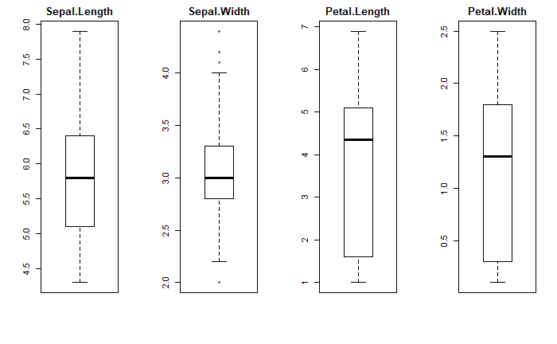

```r
  for(i in 1:4) {
  boxplot(x[,i], main=names(iris)[i])
  }
```

```r
dat
```

| Sepal.Length | Sepal.Width | Petal.Length | Petal.Width | Species |
| --- | --- | --- | --- | --- |
| 5.1 | 3.5 | 1.4 | 0.2 | setosa |
| 4.9 | 3.0 | 1.4 | 0.2 | setosa |
| 4.7 | 3.2 | 1.3 | 0.2 | setosa |
| 4.6 | 3.1 | 1.5 | 0.2 | setosa |
| 5.0 | 3.6 | 1.4 | 0.2 | setosa |
| 5.4 | 3.9 | 1.7 | 0.4 | setosa |
| 4.6 | 3.4 | 1.4 | 0.3 | setosa |
| 5.0 | 3.4 | 1.5 | 0.2 | setosa |
| 4.4 | 2.9 | 1.4 | 0.2 | setosa |
| 4.9 | 3.1 | 1.5 | 0.1 | setosa |

[output cut: 140 more lines]

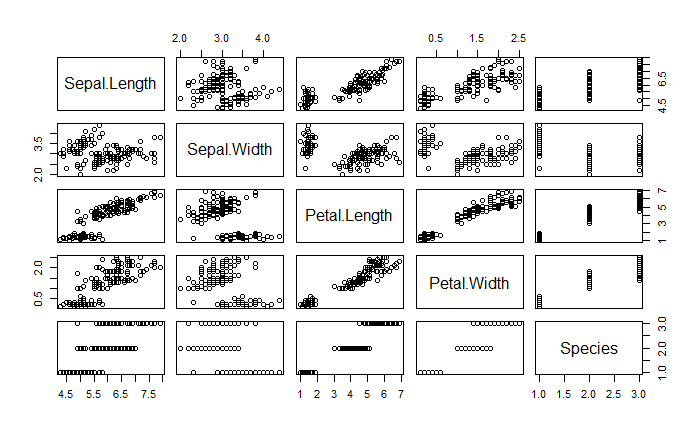

```r
pairs(dat)
```

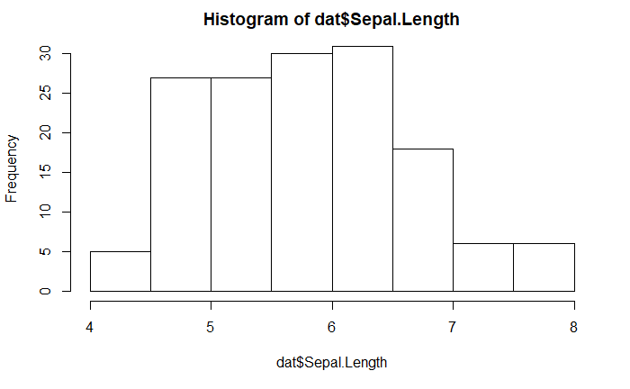

```r
hist(dat$Sepal.Length)
```

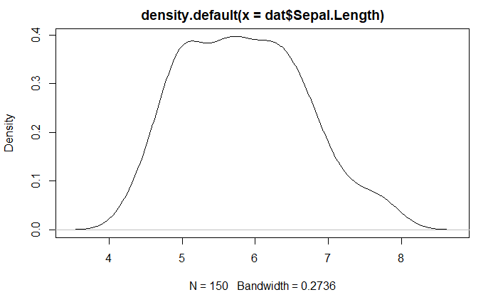

```r
plot(density(dat$Sepal.Length))
```

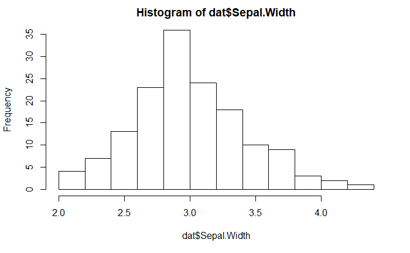

```r
hist(dat$Sepal.Width)
```

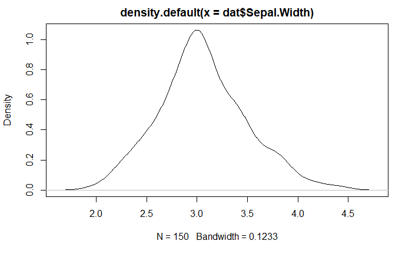

```r
plot(density(dat$Sepal.Width))
```

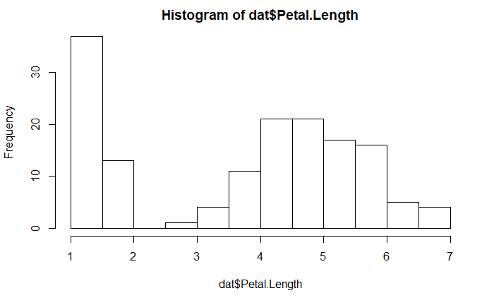

```r
hist(dat$Petal.Length)
```

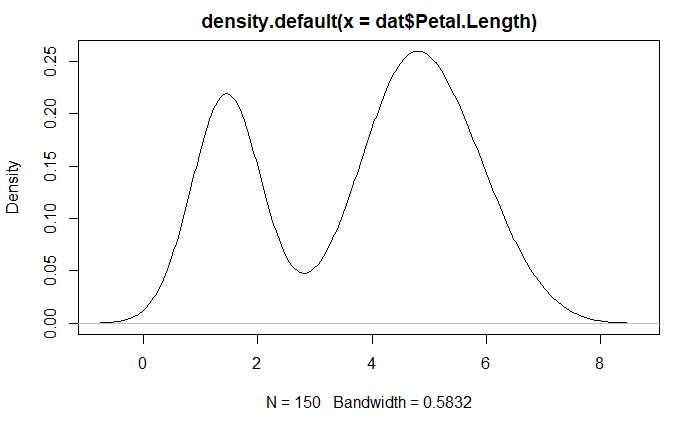

```r
plot(density(dat$Petal.Length))
```

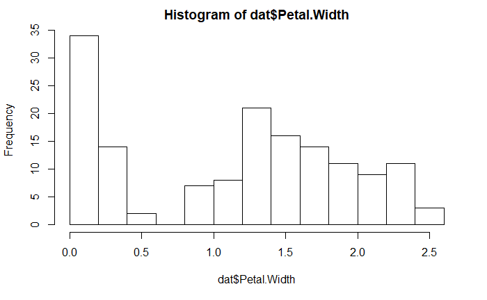

```r
hist(dat$Petal.Width)
```

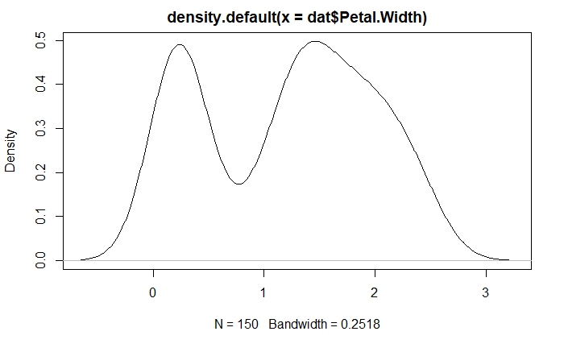

```r
plot(density(dat$Petal.Width))
```

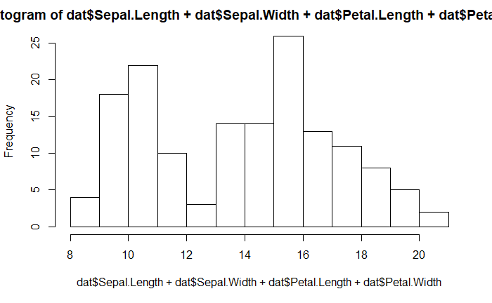

```r
hist(dat$Sepal.Length + dat$Sepal.Width+dat$Petal.Length + dat$Petal.Width)
```

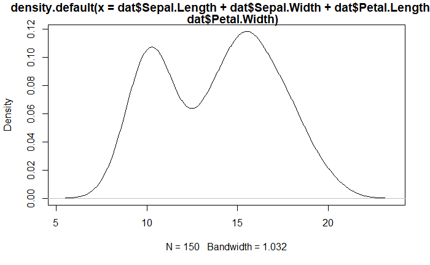

```r
plot(density(dat$Sepal.Length + dat$Sepal.Width+dat$Petal.Length + dat$Petal.Width))
```

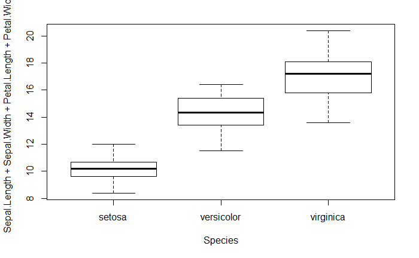

```r
boxplot(Sepal.Length+Sepal.Width+Petal.Length + Petal.Width ~ Species, data = dat)
```

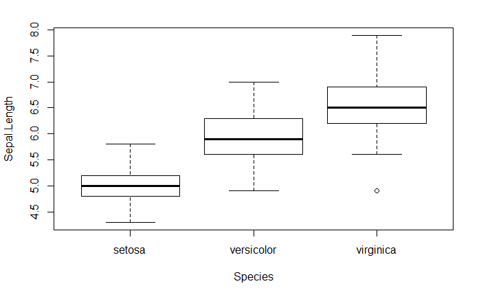

```r
boxplot(Sepal.Length~Species, data = dat)
```

Model: Gaussian mixture model: When we fit a mixture model to data, we usually have the $y$ values and do not know which ‘population’ they belong to. The hierarchical model looks like:
$$y_{i}|z_i,\theta \sim \mathcal{N}_{z_i}(\mu_{z_i},\sigma^2), \hspace{0.5cm} i = 1,\dots,n$$

```r
y = dat$Sepal.Length + dat$Sepal.Width + dat$Petal.Length+ dat$Petal.Width
y
```

```
  [1] 10.2  9.5  9.4  9.4 10.2 11.4  9.7 10.1  8.9  9.6 10.8 10.0  9.3  8.5 11.2 12.0 11.0 10.3 11.5 10.7 10.7 10.7  9.4 10.6 10.3  9.8 10.4 10.4 10.2  9.7  9.7 10.7
 [33] 10.9 11.3  9.7  9.6 10.5 10.0  8.9 10.2 10.1  8.4  9.1 10.7 11.2  9.5 10.7  9.4 10.7  9.9 16.3 15.6 16.4 13.1 15.4 14.3 15.9 11.6 15.4 13.2 11.5 14.6 13.2 15.1
 [65] 13.4 15.6 14.6 13.6 14.4 13.1 15.7 14.2 15.2 14.8 14.9 15.4 15.8 16.4 14.9 12.8 12.8 12.6 13.6 15.4 14.4 15.5 16.0 14.3 14.0 13.3 13.7 15.1 13.6 11.6 13.8 14.1
 [97] 14.1 14.7 11.7 13.9 18.1 15.5 18.1 16.6 17.5 19.3 13.6 18.3 16.8 19.4 16.8 16.3 17.4 15.2 16.1 17.2 16.8 20.4 19.5 14.7 18.1 15.3 19.2 15.7 17.8 18.2 15.6 15.8
[129] 16.9 17.6 18.2 20.1 17.0 15.7 15.7 19.1 17.7 16.8 15.6 17.5 17.8 17.4 15.5 18.2 18.2 17.2 15.7 16.7 17.3 15.8
```

```r
(n = length(y))
```

```
[1] 150
```

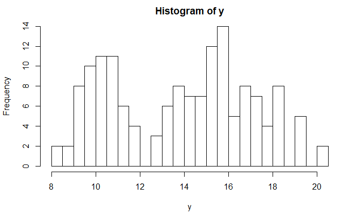

```r
#jpeg("rplot.jpg", width = 350, height = "350")
hist(y,breaks = 20)
```

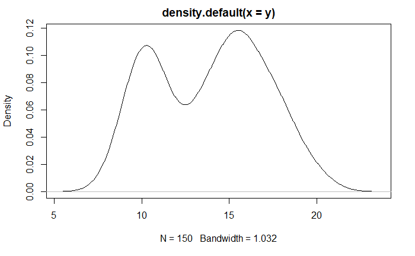

```r
plot(density(y))
```

It appears that we have two populations, but in reality there are three populations each observation belongs to. We will assume three latent variables corresponding to three different species. We will learn them, along with the mixture weights and population-specific parameters with a Bayesian hierarchical model.

Modeling using RJAGS:

```r
library("rjags")

mod_string = "model{
  for (i in 1:length(y)){
    y[i] ~ dnorm(mu[z[i]],prec)
    z[i] ~ dcat(omega)
  }

  mu[1] ~ dnorm(-1,1.0/100.0)
  mu[2] ~ dnorm(0,1.0/100.0) T(mu[1],)
  mu[3] ~ dnorm(1, 1.0/100.0) T(mu[2],)

  prec ~ dgamma(1.0/2.0, 1.0*1.0/2.0)
  sig = sqrt(1.0/prec)

  omega ~ ddirich(c(1.0,1.0,1.0))

}"
```

```r
set.seed(100)

data_jags = list(y = y)
# params = c("mu", "sig", "omega", "z[10]", "z[78]", "z[90]","z[104]", " z[115]", "z[121]", "z[82]")
params  = c("mu","sig", "omega", "z")
mod = jags.model(textConnection(mod_string), data = data_jags, n.chains = 3)
```

[output not shown]

```r
update(mod,1e3)
```

[output not shown]

```r
mod_sim = coda.samples(model = mod, variable.names = params, n.iter = 5e3)
```

[output not shown]

```r
mod_csim = as.mcmc(do.call(rbind,mod_sim))
```

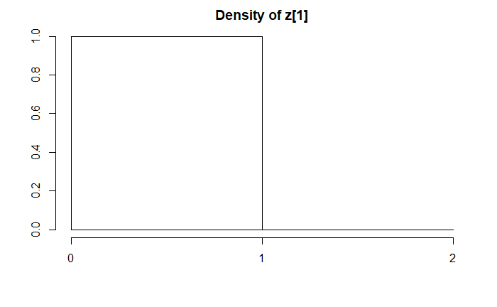

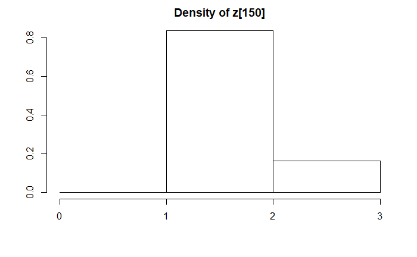

```r
densplot(mod_csim[,c("z[1]", "z[150]")])
```

```r
(pm_coeff = colMeans(mod_csim))
```

```
     mu[1]      mu[2]      mu[3]   omega[1]   omega[2]   omega[3]        sig       z[1]       z[2]       z[3]       z[4]       z[5]       z[6]       z[7]       z[8]
10.3550718 14.9545883 17.7769847  0.3723625  0.4036969  0.2239406  1.1369439  1.0002667  1.0000667  1.0001333  1.0001333  1.0004000  1.0158000  1.0000667  1.0005333
      z[9]      z[10]      z[11]      z[12]      z[13]      z[14]      z[15]      z[16]      z[17]      z[18]      z[19]      z[20]      z[21]      z[22]      z[23]
 1.0000000  1.0000000  1.0024000  1.0001333  1.0000667  1.0000000  1.0078000  1.1063333  1.0053333  1.0005333  1.0217333  1.0018000  1.0023333  1.0019333  1.0000667
     z[24]      z[25]      z[26]      z[27]      z[28]      z[29]      z[30]      z[31]      z[32]      z[33]      z[34]      z[35]      z[36]      z[37]      z[38]
 1.0019333  1.0007333  1.0000667  1.0007333  1.0004667  1.0006000  1.0001333  1.0001333  1.0019333  1.0043333  1.0122000  1.0002000  1.0003333  1.0010000  1.0002000
     z[39]      z[40]      z[41]      z[42]      z[43]      z[44]      z[45]      z[46]      z[47]      z[48]      z[49]      z[50]      z[51]      z[52]      z[53]
 1.0000667  1.0004000  1.0003333  1.0000000  1.0000000  1.0014667  1.0079333  1.0002000  1.0019333  1.0000667  1.0020667  1.0001333  2.3424000  2.1181333  2.3849333
     z[54]      z[55]      z[56]      z[57]      z[58]      z[59]      z[60]      z[61]      z[62]      z[63]      z[64]      z[65]      z[66]      z[67]      z[68]
 1.8284000  2.0837333  2.0110000  2.1912000  1.0303333  2.0812667  1.8695333  1.0230667  2.0242000  1.8748000  2.0503333  1.9258000  2.1179333  2.0231333  1.9662667
     z[69]      z[70]      z[71]      z[72]      z[73]      z[74]      z[75]      z[76]      z[77]      z[78]      z[79]      z[80]      z[81]      z[82]      z[83]
 2.0146000  1.8258000  2.1404000  2.0044667  2.0617333  2.0327333  2.0366667  2.0862000  2.1666000  2.3894667  2.0348000  1.6430667  1.6388000  1.4753333  1.9628000
     z[84]      z[85]      z[86]      z[87]      z[88]      z[89]      z[90]      z[91]      z[92]      z[93]      z[94]      z[95]      z[96]      z[97]      z[98]
 2.0865333  2.0134667  2.0996000  2.2220000  2.0101333  1.9969333  1.8990000  1.9774000  2.0507333  1.9640000  1.0320000  1.9836000  2.0011333  2.0010000  2.0231333
     z[99]     z[100]     z[101]     z[102]     z[103]     z[104]     z[105]     z[106]     z[107]     z[108]     z[109]     z[110]     z[111]     z[112]     z[113]
 1.0438000  1.9886000  2.9340667  2.0972667  2.9280667  2.4835333  2.8329333  2.9851333  1.9631333  2.9501333  2.5792000  2.9846667  2.5716667  2.3377333  2.8074000
    z[114]     z[115]     z[116]     z[117]     z[118]     z[119]     z[120]     z[121]     z[122]     z[123]     z[124]     z[125]     z[126]     z[127]     z[128]
 2.0620000  2.2596667  2.7454667  2.5797333  2.9940667  2.9882000  2.0255333  2.9307333  2.0711333  2.9824667  2.1404667  2.8971333  2.9424000  2.1169333  2.1660667
    z[129]     z[130]     z[131]     z[132]     z[133]     z[134]     z[135]     z[136]     z[137]     z[138]     z[139]     z[140]     z[141]     z[142]     z[143]
 2.6255333  2.8589333  2.9394000  2.9927333  2.6712000  2.1378000  2.1395333  2.9821333  2.8744000  2.5773333  2.1184667  2.8373333  2.8921333  2.8088000  2.1048667
    z[144]     z[145]     z[146]     z[147]     z[148]     z[149]     z[150]
 2.9400000  2.9415333  2.7497333  2.1442667  2.5342667  2.7765333  2.1610667
```

```r
(a = pm_coeff[8:57])
```

```
    z[1]     z[2]     z[3]     z[4]     z[5]     z[6]     z[7]     z[8]     z[9]    z[10]    z[11]    z[12]    z[13]    z[14]    z[15]    z[16]    z[17]    z[18]
1.000267 1.000067 1.000133 1.000133 1.000400 1.015800 1.000067 1.000533 1.000000 1.000000 1.002400 1.000133 1.000067 1.000000 1.007800 1.106333 1.005333 1.000533
   z[19]    z[20]    z[21]    z[22]    z[23]    z[24]    z[25]    z[26]    z[27]    z[28]    z[29]    z[30]    z[31]    z[32]    z[33]    z[34]    z[35]    z[36]
1.021733 1.001800 1.002333 1.001933 1.000067 1.001933 1.000733 1.000067 1.000733 1.000467 1.000600 1.000133 1.000133 1.001933 1.004333 1.012200 1.000200 1.000333
   z[37]    z[38]    z[39]    z[40]    z[41]    z[42]    z[43]    z[44]    z[45]    z[46]    z[47]    z[48]    z[49]    z[50]
1.001000 1.000200 1.000067 1.000400 1.000333 1.000000 1.000000 1.001467 1.007933 1.000200 1.001933 1.000067 1.002067 1.000133
```

```r
(a_tab = a>0.5 & a<1.5)
```

```
 z[1]  z[2]  z[3]  z[4]  z[5]  z[6]  z[7]  z[8]  z[9] z[10] z[11] z[12] z[13] z[14] z[15] z[16] z[17] z[18] z[19] z[20] z[21] z[22] z[23] z[24] z[25] z[26] z[27]
 TRUE  TRUE  TRUE  TRUE  TRUE  TRUE  TRUE  TRUE  TRUE  TRUE  TRUE  TRUE  TRUE  TRUE  TRUE  TRUE  TRUE  TRUE  TRUE  TRUE  TRUE  TRUE  TRUE  TRUE  TRUE  TRUE  TRUE
z[28] z[29] z[30] z[31] z[32] z[33] z[34] z[35] z[36] z[37] z[38] z[39] z[40] z[41] z[42] z[43] z[44] z[45] z[46] z[47] z[48] z[49] z[50]
 TRUE  TRUE  TRUE  TRUE  TRUE  TRUE  TRUE  TRUE  TRUE  TRUE  TRUE  TRUE  TRUE  TRUE  TRUE  TRUE  TRUE  TRUE  TRUE  TRUE  TRUE  TRUE  TRUE
```

```r
table(a_tab)
```

```
a_tab
TRUE
  50
```

```r
(b = pm_coeff[58:107])
```

```
   z[51]    z[52]    z[53]    z[54]    z[55]    z[56]    z[57]    z[58]    z[59]    z[60]    z[61]    z[62]    z[63]    z[64]    z[65]    z[66]    z[67]    z[68]
2.342400 2.118133 2.384933 1.828400 2.083733 2.011000 2.191200 1.030333 2.081267 1.869533 1.023067 2.024200 1.874800 2.050333 1.925800 2.117933 2.023133 1.966267
   z[69]    z[70]    z[71]    z[72]    z[73]    z[74]    z[75]    z[76]    z[77]    z[78]    z[79]    z[80]    z[81]    z[82]    z[83]    z[84]    z[85]    z[86]
2.014600 1.825800 2.140400 2.004467 2.061733 2.032733 2.036667 2.086200 2.166600 2.389467 2.034800 1.643067 1.638800 1.475333 1.962800 2.086533 2.013467 2.099600
   z[87]    z[88]    z[89]    z[90]    z[91]    z[92]    z[93]    z[94]    z[95]    z[96]    z[97]    z[98]    z[99]   z[100]
2.222000 2.010133 1.996933 1.899000 1.977400 2.050733 1.964000 1.032000 1.983600 2.001133 2.001000 2.023133 1.043800 1.988600
```

```r
(b_tab = b>1.5 & b<2.5)
```

```
 z[51]  z[52]  z[53]  z[54]  z[55]  z[56]  z[57]  z[58]  z[59]  z[60]  z[61]  z[62]  z[63]  z[64]  z[65]  z[66]  z[67]  z[68]  z[69]  z[70]  z[71]  z[72]  z[73]
  TRUE   TRUE   TRUE   TRUE   TRUE   TRUE   TRUE  FALSE   TRUE   TRUE  FALSE   TRUE   TRUE   TRUE   TRUE   TRUE   TRUE   TRUE   TRUE   TRUE   TRUE   TRUE   TRUE
 z[74]  z[75]  z[76]  z[77]  z[78]  z[79]  z[80]  z[81]  z[82]  z[83]  z[84]  z[85]  z[86]  z[87]  z[88]  z[89]  z[90]  z[91]  z[92]  z[93]  z[94]  z[95]  z[96]
  TRUE   TRUE   TRUE   TRUE   TRUE   TRUE   TRUE   TRUE  FALSE   TRUE   TRUE   TRUE   TRUE   TRUE   TRUE   TRUE   TRUE   TRUE   TRUE   TRUE  FALSE   TRUE   TRUE
 z[97]  z[98]  z[99] z[100]
  TRUE   TRUE  FALSE   TRUE
```

```r
table(b_tab)
```

```
b_tab
FALSE  TRUE
    5    45
```

```r
(c = pm_coeff[108:157])
```

```
  z[101]   z[102]   z[103]   z[104]   z[105]   z[106]   z[107]   z[108]   z[109]   z[110]   z[111]   z[112]   z[113]   z[114]   z[115]   z[116]   z[117]   z[118]
2.934067 2.097267 2.928067 2.483533 2.832933 2.985133 1.963133 2.950133 2.579200 2.984667 2.571667 2.337733 2.807400 2.062000 2.259667 2.745467 2.579733 2.994067
  z[119]   z[120]   z[121]   z[122]   z[123]   z[124]   z[125]   z[126]   z[127]   z[128]   z[129]   z[130]   z[131]   z[132]   z[133]   z[134]   z[135]   z[136]
2.988200 2.025533 2.930733 2.071133 2.982467 2.140467 2.897133 2.942400 2.116933 2.166067 2.625533 2.858933 2.939400 2.992733 2.671200 2.137800 2.139533 2.982133
  z[137]   z[138]   z[139]   z[140]   z[141]   z[142]   z[143]   z[144]   z[145]   z[146]   z[147]   z[148]   z[149]   z[150]
2.874400 2.577333 2.118467 2.837333 2.892133 2.808800 2.104867 2.940000 2.941533 2.749733 2.144267 2.534267 2.776533 2.161067
```

```r
(c_tab = c>2.5 & c<3.5)
```

```
z[101] z[102] z[103] z[104] z[105] z[106] z[107] z[108] z[109] z[110] z[111] z[112] z[113] z[114] z[115] z[116] z[117] z[118] z[119] z[120] z[121] z[122] z[123]
  TRUE  FALSE   TRUE  FALSE   TRUE   TRUE  FALSE   TRUE   TRUE   TRUE   TRUE  FALSE   TRUE  FALSE  FALSE   TRUE   TRUE   TRUE   TRUE  FALSE   TRUE  FALSE   TRUE
z[124] z[125] z[126] z[127] z[128] z[129] z[130] z[131] z[132] z[133] z[134] z[135] z[136] z[137] z[138] z[139] z[140] z[141] z[142] z[143] z[144] z[145] z[146]
 FALSE   TRUE   TRUE  FALSE  FALSE   TRUE   TRUE   TRUE   TRUE   TRUE  FALSE  FALSE   TRUE   TRUE   TRUE  FALSE   TRUE   TRUE   TRUE  FALSE   TRUE   TRUE   TRUE
z[147] z[148] z[149] z[150]
 FALSE   TRUE   TRUE  FALSE
```

```r
table(c_tab)
```

```
c_tab
FALSE  TRUE
   17    33
```

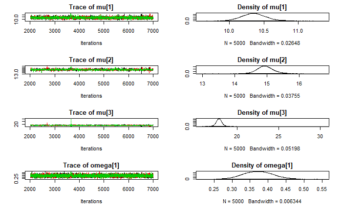

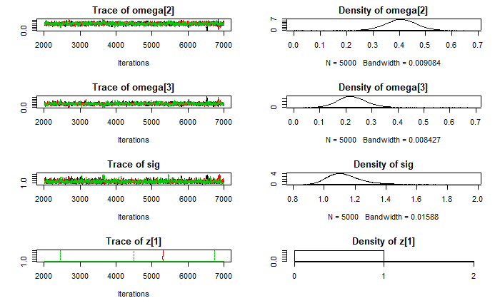

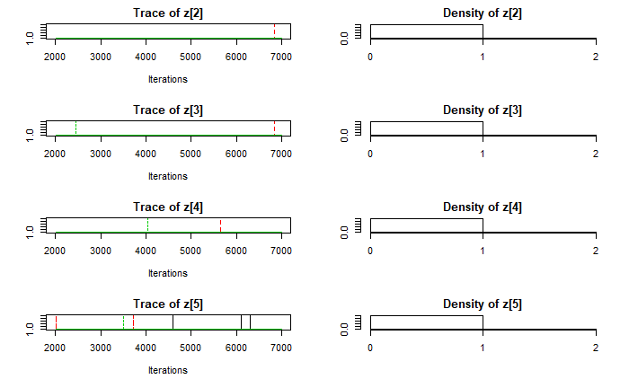

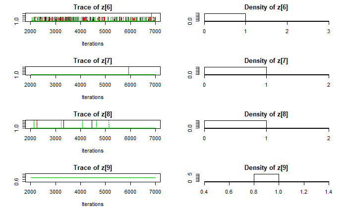

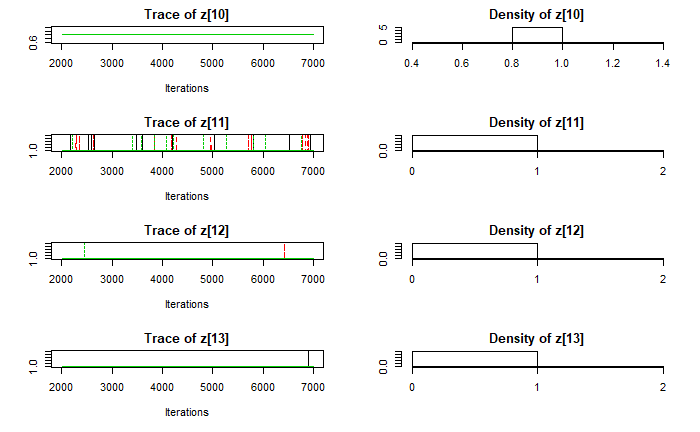

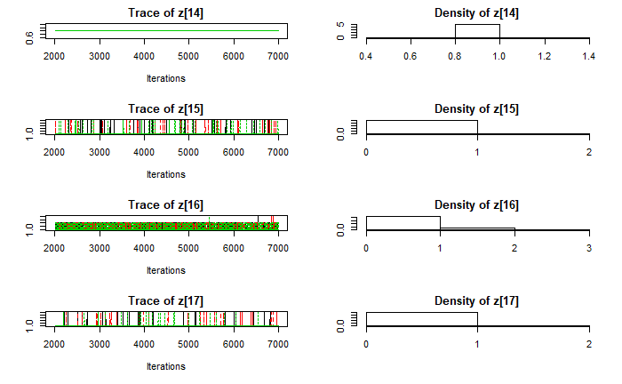

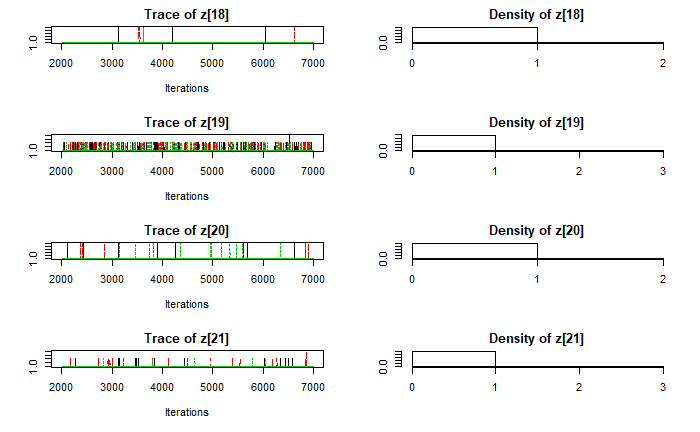

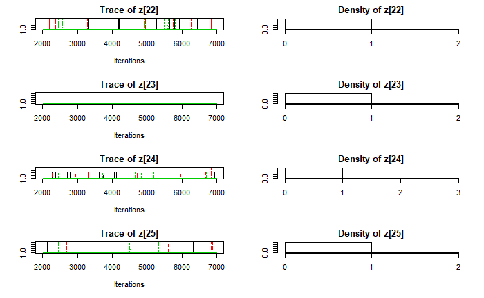

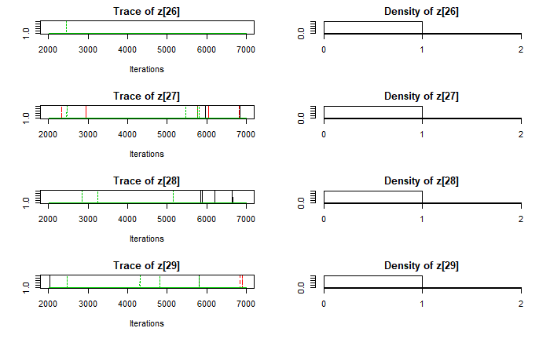

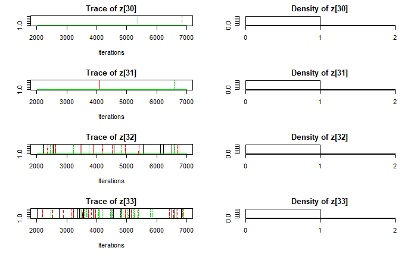

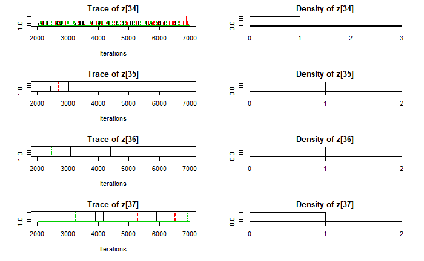

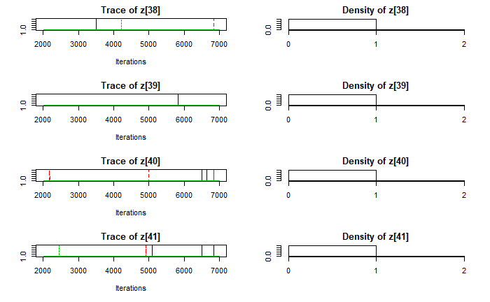

[28 more figures not shown]

```r
plot(mod_sim)
```